# DATA252: Review of Simple Linear Regression

Kitada Smalley

## Learning Objectives

In this lesson students will review the main concepts of Simple Linear Regression.

- How to fit a model
- Graphics a model
- Checking model fit and diagnostics
- Model inference

## I. Motivating Example

### Import the Data

These laptop price data come from Kaggle.

```r
### use raw file from github
laptop_price <- read.csv("https://raw.githubusercontent.com/kitadasmalley/DATA252/main/Data/laptop_price.csv")
```

### Step Zero: Wrangle Data

```r
## TIDYVERSE
#install.packages("tidyverse")
library(tidyverse)

### convert to dollars
laptop_price<-laptop_price%>%
  mutate(Price_dollar=Price_euros*1.09)

# TAKE OFF LABELS for GB
unique(laptop_price$Ram)
```

```
## [1] "8GB"  "16GB" "4GB"  "2GB"  "12GB" "6GB"  "32GB" "24GB" "64GB"
```

```r
#str_remove()
laptop_price$Ram_GB<-str_remove(laptop_price$Ram, "GB")
laptop_price$Ram_GB<-as.numeric(laptop_price$Ram_GB)
unique(laptop_price$Ram_GB)
```

```
## [1]  8 16  4  2 12  6 32 24 64
```

### Step One: Look at the Data

- Explanatory (X): RAM in GB
- Repsonse (Y): Price in Dollars

#### Make a Scatterplot

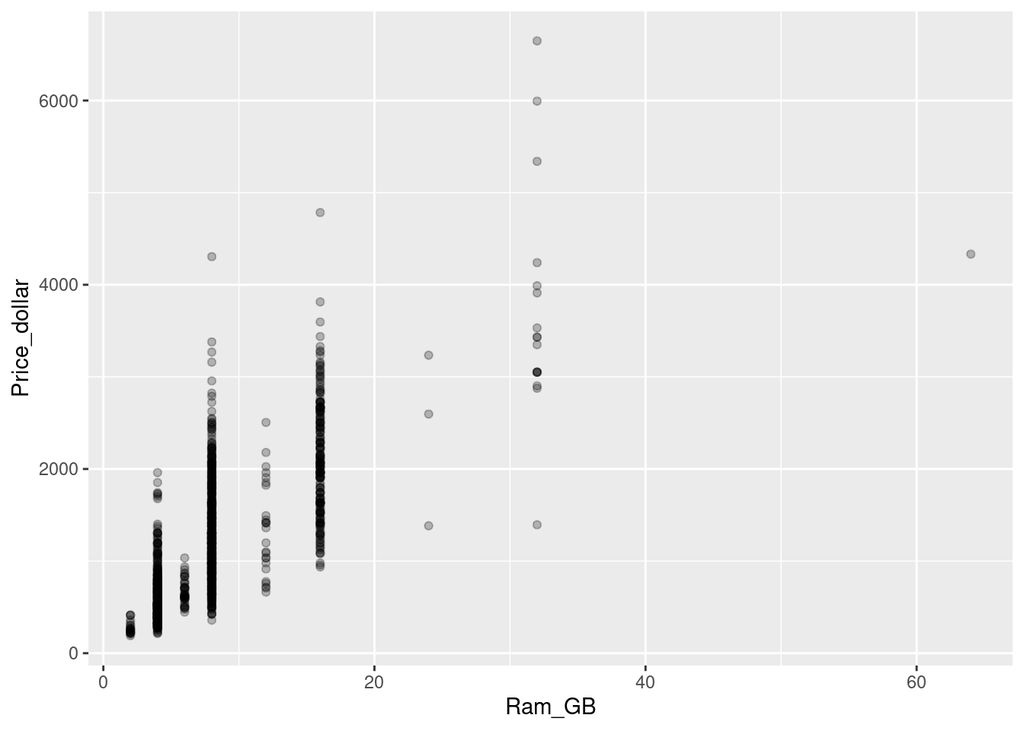

```r
# SCATTERPLOT
ggplot(data=laptop_price,
       aes(y=Price_dollar, x=Ram_GB))+
  geom_point(alpha=.25)
```

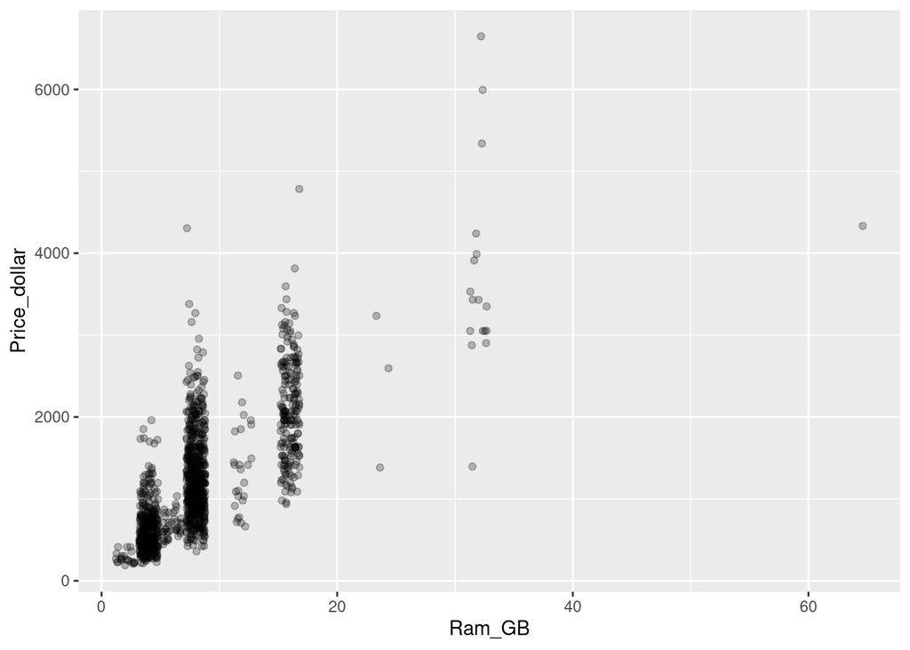

```r
# JITTER ADDS NOISE
ggplot(data=laptop_price,
       aes(y=Price_dollar, x=Ram_GB))+
  geom_jitter(alpha=.25)
```

### Step Two: Assume a Model Form

#### Non-Parametric

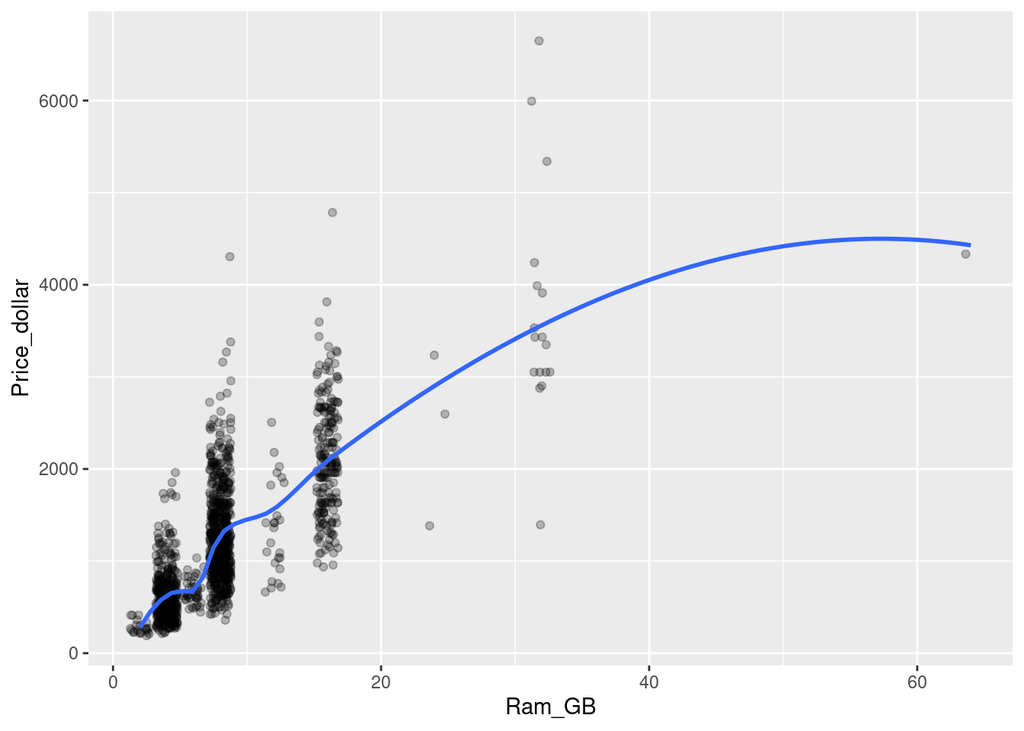

```r
ggplot(data=laptop_price,
       aes(y=Price_dollar, x=Ram_GB))+
  geom_jitter(alpha=.25)+
  geom_smooth(method="loess", se=FALSE)
```

#### Parametric

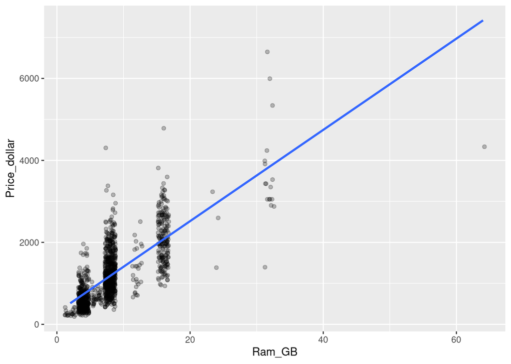

```r
ggplot(data=laptop_price,
       aes(y=Price_dollar, x=Ram_GB))+
  geom_jitter(alpha=.25)+
  geom_smooth(method="lm", se=FALSE)
```

We’re going to go with a simple linear model

## II. Fitting A Simple Linear Regression (SLR) Model

This model has the form:
$$Y_i=\beta_0+\beta_1 x_i
+\varepsilon_i$$

This might look familar to $Y=mx+b$, which was called slope-intercept form.

### Step Three: Estimate Model Coefficients

```r
mod1<-lm(Price_dollar~Ram_GB, data=laptop_price)
summary(mod1)
```

```
##
## Call:
## lm(formula = Price_dollar ~ Ram_GB, data = laptop_price)
##
## Residuals:
##     Min      1Q  Median      3Q     Max
## -3084.4  -322.7  -104.3   249.7  3122.6
##
## Coefficients:
##             Estimate Std. Error t value Pr(>|t|)
## (Intercept)   291.57      27.26   10.70   <2e-16 ***
## Ram_GB        111.34       2.78   40.04   <2e-16 ***
## ---
## Signif. codes:  0 '***' 0.001 '**' 0.01 '*' 0.05 '.' 0.1 ' ' 1
##
## Residual standard error: 510.1 on 1301 degrees of freedom
## Multiple R-squared:  0.5521, Adjusted R-squared:  0.5517
## F-statistic:  1603 on 1 and 1301 DF,  p-value: < 2.2e-16
```

We can estimate the parameters:

- Y-intercept: $\hat{\beta}_0 = 291.57$
- Slope: $\hat{\beta}_1 = 111.34$

### Step Four: Error Estimation

#### Standard Errors

We can estimate the error associated estimating these parameters: * Standard Error for Y-intercept: $SE(\hat{\beta}_0) = 27.26$ * Standard Error for Slope: $SE(\hat{\beta}_1) = 2.78$

#### Estimating the variance, $\sigma^2$

We can estimate the $\sigma^2$ with $s^2$:
$$s^2=\frac{1}{n-2}\sum_{i=1}^n(Y_i-\hat{Y}_i)^2$$

The quantity $s^2$ is called the **mean squared error (MSE)**.

The denominator $n-2$ is referred to as the residual regrees of freedom.

Rather than $s^2$ we often use $s$:
$$s=\sqrt{\frac{1}{n-2}\sum_{i=1}^n(Y_i-\hat{Y}_i)^2}$$

We can find this value in the R output, but we can also check it:

```r
sqrt(sum(mod1$residuals^2)/1301)
```

```
## [1] 510.1363
```

We can also use the `broom` package! Using the `glance()` function in `broom` accesses the model metrics.

```r
library(broom)

mod1%>%
  glance()%>%
  pull(sigma)
```

```
## [1] 510.1363
```

## III. Assessing Model Assumptions

### Tools for assessment:

- Residual Plot
- QQ (Quantile-Quantile) Plot
- Leverage vs Residual Plot

#### Residual Plot from Scratch

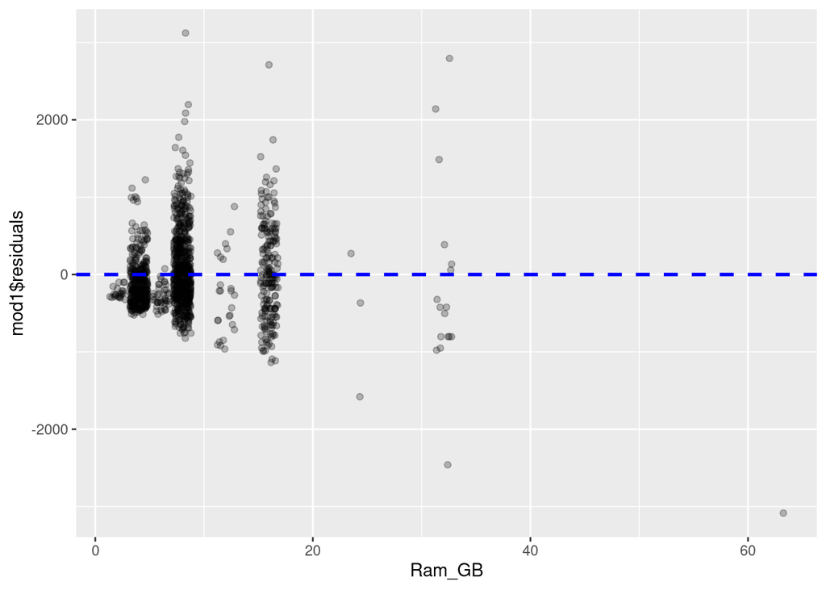

```r
ggplot(data=laptop_price, aes(x=Ram_GB, y=mod1$residuals))+
  geom_jitter(alpha=.25)+
  geom_hline(yintercept = 0, lty=2, lwd=1, color="blue")
```

#### QQ Plot from Scratch

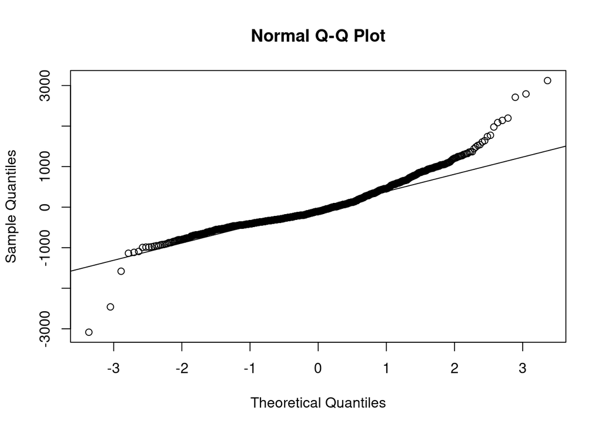

```r
qqnorm(mod1$residuals)
qqline(mod1$residuals)
```

#### Plot Function

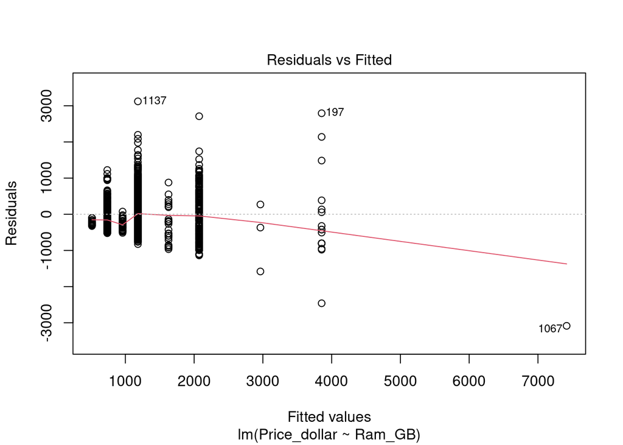

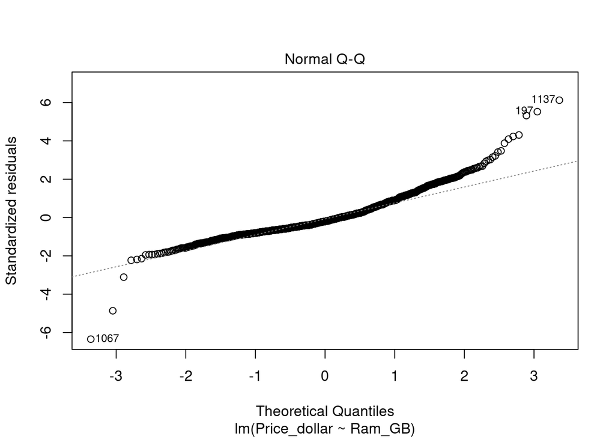

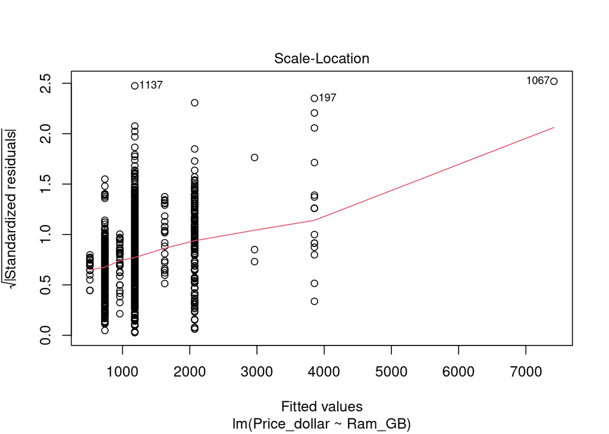

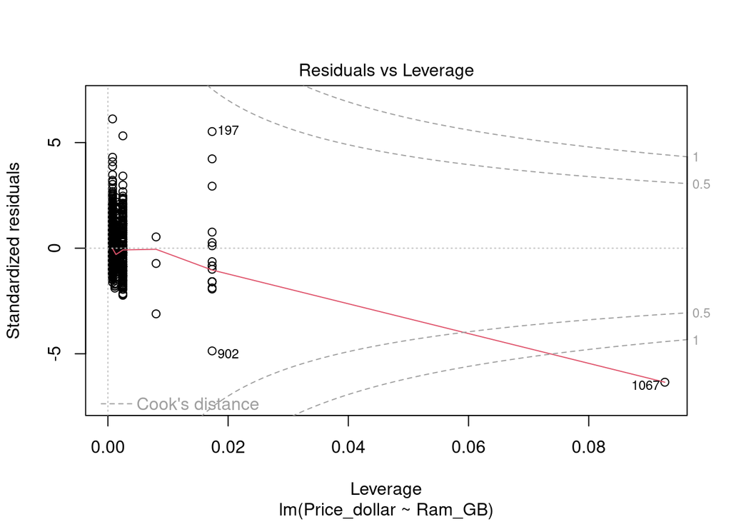

```r
plot(mod1)
```

### Remove the Outlier

```r
laptop_price_wo<-laptop_price%>%
  filter(Ram_GB<40)

mod2<-lm(Price_dollar~Ram_GB, data=laptop_price_wo)
summary(mod2)
```

```
##
## Call:
## lm(formula = Price_dollar ~ Ram_GB, data = laptop_price_wo)
##
## Residuals:
##      Min       1Q   Median       3Q      Max
## -2595.51  -312.70   -97.74   237.54  3122.12
##
## Coefficients:
##             Estimate Std. Error t value Pr(>|t|)
## (Intercept)  247.098     27.714   8.916   <2e-16 ***
## Ram_GB       116.954      2.873  40.702   <2e-16 ***
## ---
## Signif. codes:  0 '***' 0.001 '**' 0.01 '*' 0.05 '.' 0.1 ' ' 1
##
## Residual standard error: 502.4 on 1300 degrees of freedom
## Multiple R-squared:  0.5603, Adjusted R-squared:   0.56
## F-statistic:  1657 on 1 and 1300 DF,  p-value: < 2.2e-16
```

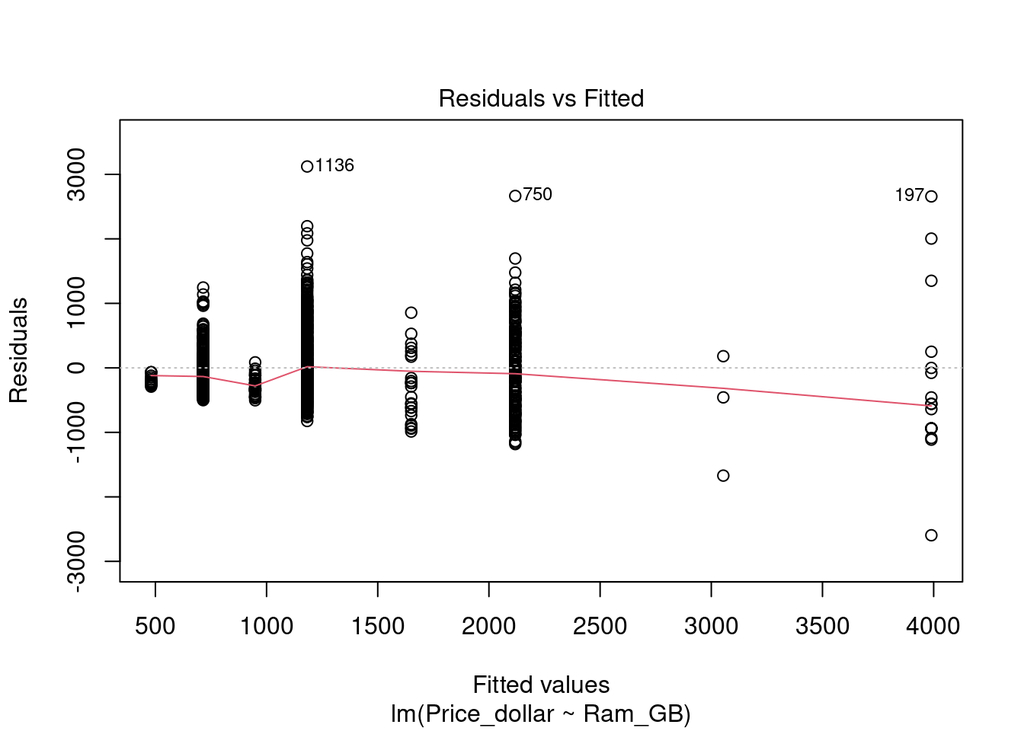

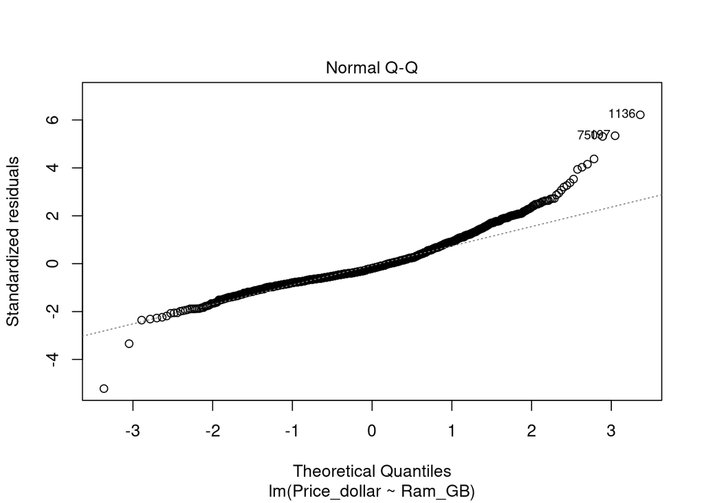

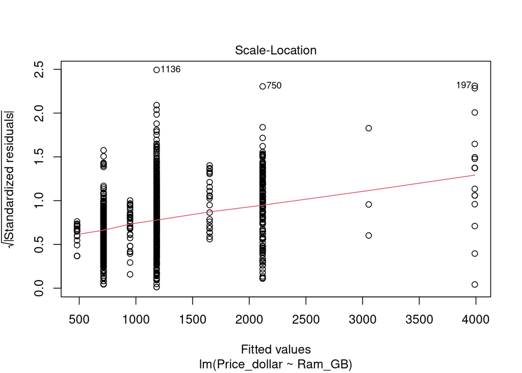

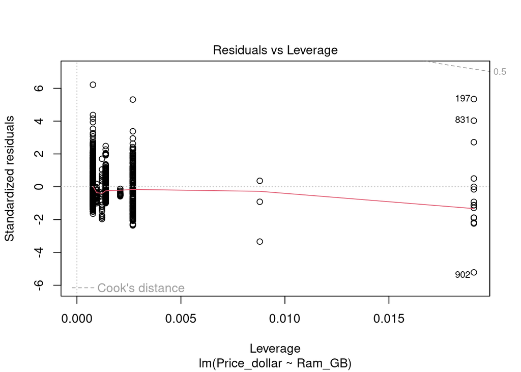

```r
plot(mod2)
```

## IV. Inference

### Step Five: Hypothesis Testing for Parameters

#### Hypothesis Testing for Slope

##### Hypotheses:

- Null Hypothesis: $H_0: \beta_1 = 0$
- Alternative Hypothesis:
- $H_A: \beta_1 \neq 0$ (two-sided)
- $H_A: \beta_1 > 0$ (one-sided upper)
- $H_A: \beta_1 < 0$ (one-sided lower)

##### Test Statistic:

$$t=\frac{\hat{\beta}_1}{SE({\hat{\beta}_1})}$$

where
$$SE(\hat{\beta}_1)=\sqrt{\frac{s^2}{\sum_{i=1}^n
(x_i-\bar{x})^2}}$$

##### Reference Distribution:

T-distribution with $n-2$ degrees of freedom.

##### P-value:

```r
beta1 <- mod2$coefficients[2]
beta1
```

```
##   Ram_GB
## 116.9538
```

```r
beta1SE <- sqrt((sum(mod2$residuals^2))/1300/sum((laptop_price_wo$Ram_GB - mean(laptop_price_wo$Ram_GB))^2))
beta1SE
```

```
## [1] 2.873447
```

```r
testStat<- beta1/beta1SE

pt(-abs(testStat), 1300, lower.tail=TRUE)*2
```

```
##        Ram_GB
## 3.286723e-234
```

### Step Six: Confidence Interval for Parameters

Confidence intervals take the form

$$\text{Point Estimate} \pm \text{Critical
Value} \times \text{Standard Error}$$

#### Confidence Interval for Slope

$$\hat{\beta}_1 \pm t_{df=n-2, \alpha/2}
\times \sqrt{\frac{s^2}{\sum_{i=1}^n (x_i-\bar{x})^2}}$$

##### Point Estiamte: $\hat{\beta}_1$

```r
beta1 <- mod2$coefficients[2]
beta1
```

```
##   Ram_GB
## 116.9538
```

##### Critical Value: $t_{df=n-2, \alpha/2}$

We define the significance level $\alpha$, therefore we need to find the $1-\alpha/2$ quantile. Typically, the default significance level used is $\alpha=0.05$, thus the percentile we look for is $97.5%$.

Recall that the degrees of freedom are $n-2$.

```r
qt(0.975, df=1302-2)
```

```
## [1] 1.96179
```

##### Standard Error: $SE(\hat{\beta}_1)=\sqrt{\frac{s^2}{\sum_{i=1}^n (x_i-\bar{x})^2}}$

```r
beta1SE <- sqrt((sum(mod2$residuals^2))/1300/sum((laptop_price_wo$Ram_GB - mean(laptop_price_wo$Ram_GB))^2))
beta1SE
```

```
## [1] 2.873447
```

#### Pull this all together:

```r
beta1 +c(-1,1)*qt(0.975, df=1302-2)*beta1SE
```

```
## [1] 111.3167 122.5909
```

We can check this with the confint function in R:

```r
confint(mod2)
```

```
##                2.5 %   97.5 %
## (Intercept) 192.7293 301.4672
## Ram_GB      111.3167 122.5909
```

## V. Prediction

### Step Seven: Confidence and Prediction Intervals for an Observation

#### Using the Model for Prediction

```r
newdata=data.frame(Ram_GB=10)
predict(mod2, newdata)
```

```
##        1
## 1416.636
```

#### Confidence Interval for a mean response

```r
predict(mod2, newdata, interval="confidence")
```

```
##        fit      lwr      upr
## 1 1416.636 1387.764 1445.509
```

#### Prediction Interval for a new response

```r
predict(mod2, newdata, interval="predict")
```

```
##        fit      lwr    upr
## 1 1416.636 430.6721 2402.6
```

#### Adding Confidence and Prediction Bands

```r
confBand<-predict(mod2, interval="confidence")
predBand<-predict(mod2, interval="predict")
```

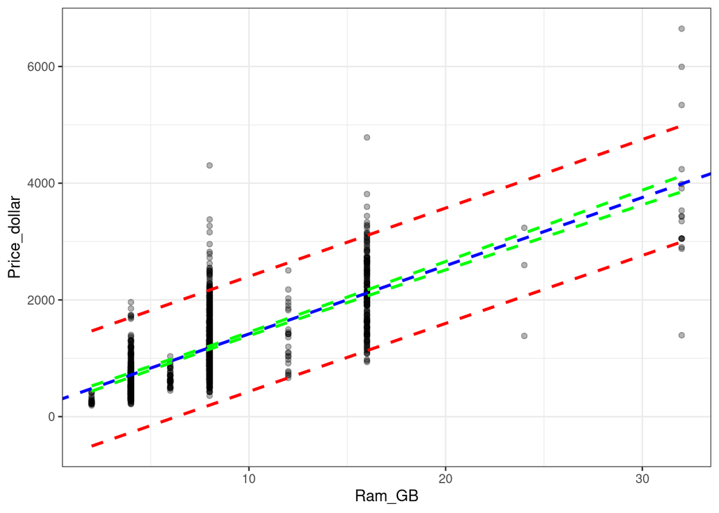

```r
colnames(predBand)<-c("fit2", "lwr2", "upr2")


newDF<-cbind(laptop_price_wo, confBand, predBand)

ggplot(newDF, aes(x=Ram_GB, y=Price_dollar))+
  geom_point(alpha=.3)+
  geom_abline(slope=mod2$coefficients[2], intercept=mod2$coefficients[1],
              color="blue", lty=2, lwd=1)+
  geom_line(aes(y=lwr), color="green", lty=2, lwd=1)+
  geom_line(aes(y=upr), color="green", lty=2, lwd=1)+
  geom_line(aes(y=lwr2), color="red", lty=2, lwd=1)+
  geom_line(aes(y=upr2), color="red", lty=2, lwd=1)+
  theme_bw()
```

## VI. Variability

### Step Eight and Nine: Analysis of Variance

```r
anova(mod2)
```

```
## Analysis of Variance Table
##
## Response: Price_dollar
##             Df    Sum Sq   Mean Sq F value    Pr(>F)
## Ram_GB       1 418086847 418086847  1656.6 < 2.2e-16 ***
## Residuals 1300 328085970    252374
## ---
## Signif. codes:  0 '***' 0.001 '**' 0.01 '*' 0.05 '.' 0.1 ' ' 1
```

Researchers are often interested in the $R^2$ value, which is known as the coefficient of determination.

$$R^2=\frac{SS(Reg)}{SS(Tot)}=1-\frac{SS(Res)}{SS(Tot)}$$

In the case of simple linear regression we can also square the correlation.

```r
r_xy<-cor(laptop_price_wo$Ram_GB, laptop_price_wo$Price_dollar, )
r_xy^2
```

```
## [1] 0.5603083
```

We can also use the `broom()` function:

```r
mod2%>%
  glance()%>%
  pull(r.squared)
```

```
## [1] 0.5603083
```

## VII. Training and Testing

It is circular logic to assess model fit on data used to create the model. Instead, we will split the data into a training set and a testing set. We fit the model using the training set only. Then we use the test set data as a proxy for new observations to understand how the model will perform.

```r
### TEST TRAIN

dim(laptop_price_wo)
```

```
## [1] 1302   15
```

```r
# 1302

## TEST with 1/3
1302/3
```

```
## [1] 434
```

```r
# 434

set.seed(123)
testInd<-sample(1:1302, size=434, replace=FALSE)
train<-laptop_price_wo[-testInd, ]
test<-laptop_price_wo[testInd, ]

## TRAIN
trainMod<-lm(Price_dollar~Ram_GB, data=train)
summary(trainMod)
```

```
##
## Call:
## lm(formula = Price_dollar ~ Ram_GB, data = train)
##
## Residuals:
##      Min       1Q   Median       3Q      Max
## -2598.51  -320.76   -95.68   259.99  3119.77
##
## Coefficients:
##             Estimate Std. Error t value Pr(>|t|)
## (Intercept)  249.230     35.281   7.064 3.32e-12 ***
## Ram_GB       116.981      3.575  32.719  < 2e-16 ***
## ---
## Signif. codes:  0 '***' 0.001 '**' 0.01 '*' 0.05 '.' 0.1 ' ' 1
##
## Residual standard error: 514.6 on 866 degrees of freedom
## Multiple R-squared:  0.5528, Adjusted R-squared:  0.5523
## F-statistic:  1071 on 1 and 866 DF,  p-value: < 2.2e-16
```

```r
## TEST
testPred<-predict(trainMod, test)

sqrt(mean((testPred-test$Price_dollar)^2))
```

```
## [1] 476.985
```

```r
#install.packages("caret")
library(caret)
RMSE(testPred, test$Price_dollar)
```

```
## [1] 476.985
```